# Contents

1. Bipartite network
2. Tree and planarity
3. Degree
4. Shortest path
5. Component
6. Laplacian matrix

```python
import networkx as nx
import numpy as np
import matplotlib as mpl
import matplotlib.pyplot as plt
%matplotlib inline

nx.__version__, mpl.__version__
```

```
('3.1', '3.5.2')
```

# 1. Bipartite network

Consider the following bipartite network.

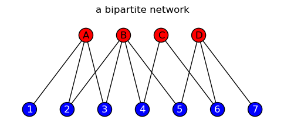

```python
B = nx.Graph()
B.add_nodes_from(range(1, 8, 1), color='b')
B.add_nodes_from(['A', 'B', 'C', 'D'], color='r')
B.add_edges_from([('A', 1), ('A', 2), ('A', 3),
                  ('B', 2), ('B', 3), ('B', 4), ('B', 5),
                  ('C', 4), ('C', 6),
                  ('D', 5), ('D', 6), ('D', 7)])

pos = {chr(i+65): (1.5+i, 2) for i in range(4)}
for i in range(7): pos[i+1] = (i, 0)

plt.figure(figsize=(6, 2))
plt.title('a bipartite network\n')
nx.draw_networkx_labels(B, pos, font_color='w',
                        labels={i: i for i in range(1, 8)})
nx.draw_networkx_labels(B, pos, font_color='k',
                        labels={A: A for A in ['A', 'B', 'C', 'D']})
nx.draw(B, pos, edgecolors='k',
        node_color=[c for n, c in B.nodes(data='color')])
```

You can check whether a network is bipartite with `is_bipartite`. It uses the two-colouring algorithm:

1. make all nodes uncoloured;
2. paint a node with one colour (say red);
3. paint its neigbhours with another colour (say blue);
4. paint its neighbours' neighbours with the first colour (say red); and
5. repeat steps 3 and 4.

A network is bipartite if its nodes can be coloured without contradiction, and each set of the coloured nodes forms a partition. *(Can you implement this?)*

```python
nx.is_bipartite(B)
```

```
True
```

**Note that our lecture notes refer to a "biadjacency matrix" as an "incidence matrix", but it means something else in NetworkX.**

```python
B1, B2 = nx.algorithms.bipartite.sets(B)
print('The first group is %s.' % B1)
print('The second group is %s.' % B2)

Ba = nx.algorithms.bipartite.biadjacency_matrix(B, B1) # a SciPy matrix
Ba = Ba.toarray().astype(int) # a NumPy array
Ba # Ba[i, j] describes whether list(B1)[i] connected to list(B2)[j]
```

```
The first group is {1, 2, 3, 4, 5, 6, 7}.
The second group is {'D', 'B', 'A', 'C'}.
```

```
array([[0, 0, 0, 1],
       [0, 1, 0, 1],
       [0, 1, 0, 1],
       [1, 1, 0, 0],
       [0, 1, 1, 0],
       [1, 0, 1, 0],
       [0, 0, 1, 0]])
```

You can also project a bipartite network on one of its partitions with `algorithms.bipartite.projected_graph`. All node attributes are preserved after the projection.

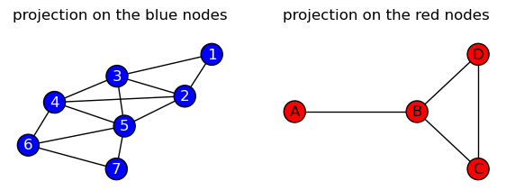

```python
BonB1 = nx.algorithms.bipartite.projected_graph(B, B1)
BonB2 = nx.algorithms.bipartite.projected_graph(B, B2)

plt.figure(figsize=(7, 2))
plt.subplot(121)
plt.title('projection on the blue nodes\n')
nx.draw_kamada_kawai(
    BonB1, with_labels=True, font_color='w', edgecolors='k',
    node_color=[c for n, c in BonB1.nodes.data('color')])
BonB1.graph['pos'] = nx.kamada_kawai_layout(BonB1)

plt.subplot(122)
plt.title('projection on the red nodes\n')
nx.draw_spectral(
    BonB2, with_labels=True, font_color='k', edgecolors='k',
    node_color=[c for n, c in BonB2.nodes.data('color')])
```

# 2. Tree and planarity

A tree is an undirected acyclic graph. It has two properties.

1. An $n$-node tree has exactly $\left(n-1\right)$ edges.
2. A tree is planar, i.e. it can be drawn on a plane without intersecting edges.

You can easily check whether a network is a tree: just see if it has one more node than its edges. You may also use the method `is_tree`. In contrast, it is more subtle to check whether a network is planar. You can do this with `check_planarity`, whose algorithm is based on [Kuratowski's theorem](https://en.wikipedia.org/wiki/Kuratowski's_theorem).

```python
print('The projection on the blue nodes is %sa tree.' %
      ('' if nx.is_tree(BonB1) else 'not '), end=' ')
print('It is %splanar.' %
      ('' if nx.is_planar(BonB1) else 'not '))
```

```
The projection on the blue nodes is not a tree. It is planar.
```

You can even visualize a planar network with `draw_planar`.

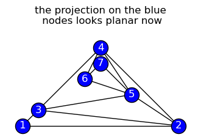

```python
plt.figure(figsize=(4, 2))
plt.title('the projection on the blue\n nodes looks planar now\n')
nx.draw_planar(BonB1, with_labels=True, font_color='w',
               edgecolors='k', node_color='b')
```

## 2.1 Minimum spanning tree

A subgraph is a spanning tree if it is a tree and contains all nodes of the network. A spanning tree is a minimum spanning tree (MST) if its edges has the smallest total weight over all spanning trees. A weighted network has a unique MST when its edges carry distinct weights.

You can compute a graph's MST with `algorithms.tree.minimum_spanning_tree`, which uses [Kruskal's algorithm (1956)](https://en.wikipedia.org/wiki/Kruskal's_algorithm): given a graph $G$,

1. create an edgeless copy $H$ of $G$;
2. add (one of) the lightest edge(s) of $G$ to $H$ if it connects two trees;
3. remove the edge from $G$; and
4. repeat steps 2 and 3 until $H$ connects all nodes.

Finally, $H$ is the MST of $G$. *(Can you implement this?)*

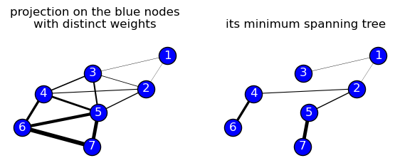

```
The minimum spanning tree is a tree.
```

```python
for u, v in BonB1.edges: BonB1[u][v]['weight'] = (u*v)/10
weights = [w for u, v, w in BonB1.edges(data='weight')]
MST = nx.algorithms.tree.minimum_spanning_tree(BonB1)

plt.figure(figsize=(7, 2))
plt.subplot(121)
plt.title('projection on the blue nodes\nwith distinct weights\n')
nx.draw(BonB1, pos=BonB1.graph['pos'], with_labels=True,
        node_color='b', font_color='w', edgecolors='k', width=weights)

plt.subplot(122)
plt.title('its minimum spanning tree\n')
nx.draw(MST, pos=BonB1.graph['pos'], with_labels=True,
        node_color='b', font_color='w', edgecolors='k',
        width=[w for u, v, w in MST.edges(data='weight')])
plt.show()

print('\nThe minimum spanning tree is %sa tree.' %
      ('' if nx.is_tree(MST) else 'not '))
```

# 3. Degree

You can use `degree` to get a dictionary-like object that contains all nodes' degrees $\left\{k\right\}$. For a `DiGraph`, `degree` returns the sum of in-degrees and out-degrees, which can be respectively retrieved with `in_degree` and `out_degree`.

```
DegreeView({0: 16, 1: 9, 2: 10, 3: 6, 4: 3, 5: 4, 6: 4, 7: 4, 8: 5, 9: 2, 10: 3, 11: 1, 12: 2, 13: 5, 14: 2, 15: 2, 16: 2, 17: 2, 18: 2, 19: 3, 20: 2, 21: 2, 22: 2, 23: 5, 24: 3, 25: 3, 26: 2, 27: 4, 28: 3, 29: 4, 30: 4, 31: 6, 32: 12, 33: 17})
```

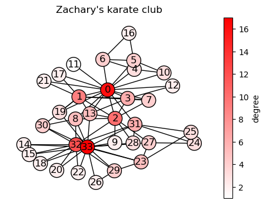

```python
karate = nx.karate_club_graph()
for u, v in karate.edges():    # make it unweighted
    del karate[u][v]['weight'] # for simplicity
degrees = [k for n, k in karate.degree]

cmap = mpl.colors.LinearSegmentedColormap.from_list('', ['w', 'r'])
norm = mpl.colors.Normalize(vmin=min(degrees), vmax=max(degrees))
smap = mpl.cm.ScalarMappable(norm, cmap)
smap.set_array([])

plt.figure(figsize=(5, 4))
plt.title('Zachary\'s karate club')
plt.colorbar(smap, fraction=0.045, pad=0.05, label='degree')
nx.draw_kamada_kawai(karate, with_labels=True,
                     edgecolors='k', node_color=degrees, cmap=cmap)

karate.degree # like a dictionary
```

There are various ways to plot a network's degree distribution $P_k$. Here I demonstrate three.

A major difference between the ways is about the method of **binning**. If you do not bin your data, you genuinely show the probability for every degree $k$. Although it is accurate, the resultant plot looks quite clumsy once the network's maximum degree is large.

Binning is also helpful for some other reasons. I will discuss its subtlety in coming tutorials.

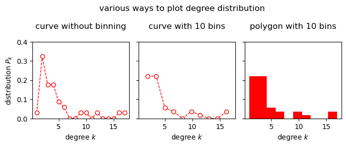

```python
fig, ax = plt.subplots(1, 3, sharex=True, sharey=True, figsize=(8, 2))
fig.suptitle('various ways to plot degree distribution', y=1.25)
plt.subplots_adjust(wspace=.1)

kmin, kmax = min(degrees), max(degrees)
ax[0].plot(range(kmin, kmax+1),
           np.array(nx.degree_histogram(karate)[kmin:])/len(karate),
           'ro--', mfc='w', lw=1)
ax[0].set_title('curve without binning\n')

prob, bin_edges = np.histogram(degrees, bins=10, density=True)
ax[1].plot((bin_edges[1:]+bin_edges[:-1])/2, prob, 'ro--', mfc='w', lw=1)
ax[1].set_title('curve with 10 bins\n')

ax[2].hist(degrees, bins=10, color='r', density=True)
ax[2].set_title('polygon with 10 bins\n')

ax[0].set_ylim(0, .4)
ax[0].set_ylabel('distribution $P_k$')
for i in range(3): ax[i].set_xlabel('degree $k$')
```

# 4. Shortest path

The length of the shortest path between two nodes may be referred to as the **(geodesic) distance** between them, whereas the shortest path may be called the **geodesic (line)**. A network's diameter is the longest distance over all pairs of nodes. In other words, no shortest paths are longer than the diameter. You can measure it with `diameter`.

NetworkX provides [many methods to find shortest paths and compute their lengths](https://networkx.github.io/documentation/stable/reference/algorithms/shortest_paths.html). The basic methods of NetworkX, viz. `shortest_path` and `shortest_path_legnth`, employ [Dijkstra's algorithm (1959)](https://en.wikipedia.org/wiki/Dijkstra%27s_algorithm). *(Can you implement this?)*

```
The diameter of Zachary's karate club is 5.
One of its longest geodesics is [14, 32, 2, 0, 5, 16].
```

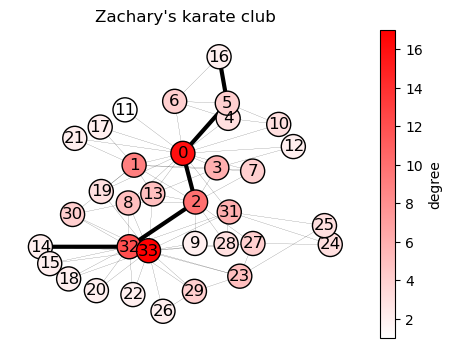

```python
d = nx.diameter(karate)
print('The diameter of Zachary\'s karate club is %d.' % d)

A = nx.to_numpy_array(karate)
A_power_sum = np.copy(A)
for p in range(2, d):
    A_power_sum += np.linalg.matrix_power(A, p)

# recall that (A**p)[i, j] == 0 implies
# the absence of any p-edge paths between i and j
sources, targets = np.where(A_power_sum == 0)
d_nodes = nx.shortest_path(karate, sources[0], targets[0])
print('One of its longest geodesics is %s.' % d_nodes)

nx.set_edge_attributes(karate, .1, 'geo')
for i in range(d):
    karate[d_nodes[i]][d_nodes[i+1]]['geo'] = 3

plt.figure(figsize=(5, 4))
plt.title('Zachary\'s karate club')
plt.colorbar(smap, fraction=0.045, pad=0.05, label='degree')
nx.draw_kamada_kawai(karate, with_labels=True,
                     edgecolors='k', node_color=degrees, cmap=cmap,
                     width=[w for u, v, w in karate.edges(data='geo')])
```

You can calculate the average distance manually, or you can use `average_shortest_path_length`.

```python
print('The average distance is %.3g.' %
      np.mean([nx.shortest_path_length(karate, u, v)
               for v in karate for u in karate if u != v])
     ) # equivlaent to nx.average_shortest_path_length(karate)
```

```
The average distance is 2.41.
```

It is sometimes more convenient to use `floyd_warshall_numpy`, which directly returns a distance matrix between nodes. It employs the [Floyd-Warshall algorithm (Floyd, 1962; Warshall, 1962)](https://en.wikipedia.org/wiki/Floyd–Warshall_algorithm) instead of Dijkstra's algorithm. *(Can you implement this?)*

You may check [Shorteset path problem](https://en.wikipedia.org/wiki/Shortest_path_problem) on Wikipedia to know more about the assumptions and the efficiency of various path-finding algorithms. Choosing an appropriate algorithm can make your life much easier.

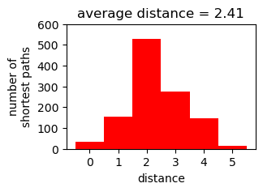

```python
dists = nx.floyd_warshall_numpy(karate).astype(int)
# dists[i, j] = the distance between i and j

plt.figure(figsize=(3, 2))
plt.hist(dists.flatten(), bins=np.arange(-0.5, d+1.5, 1), color='r')

plt.title('average distance = %.3g' % (
    dists.sum()/ len(karate) / (len(karate)-1)))
plt.xticks(range(6))
plt.yticks(range(0, 700, 100))
plt.xlabel('distance')
plt.ylabel('number of\nshortest paths')
plt.show()
```

# 5. Component

You can check a network's connectedness with `is_connected`. You should always check it before computing a network's average path length, otherwise errors may arise. In addition, you can break a network into its (connected) components with `connected_components` and count them with `number_connected_components`.

For a `DiGraph`, you must add `weakly_` or `strongly_` in front of `connected` in the three methods' names to specify whether you are checking the weakly or the strongly connected components.

```
The toy network from last tutorial is not connected.
It has 7 connected components.
```

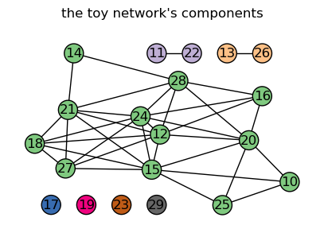

```python
toy = nx.read_gml('datasets/toy.gml')
toy = nx.relabel_nodes(toy, {n: int(n) for n in toy})
toy.graph['pos'] = {n: tuple(toy.nodes[n].values()) for n in toy}

print('The toy network from last tutorial is %sconnected.'
      % ('' if nx.is_connected(toy) else 'not '))
print('It has %d connected components.'
      % nx.number_connected_components(toy))

for i, component in enumerate(nx.connected_components(toy)):
    for node in component:
        toy.nodes[node]['c'] = i

plt.figure(figsize=(5, 3))
plt.title('the toy network\'s components\n')
nx.draw(toy, pos=toy.graph['pos'], edgecolors='k', with_labels=True,
        node_color=[c for n, c in toy.nodes(data='c')], cmap='Accent')
```

If a network is disconnected, we are usually interested in its largest component, but NetworkX does not provide a simple method to extract it directly.

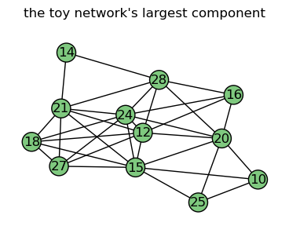

```python
lcomp = toy.subgraph(max(nx.connected_components(toy), key=len))
lcomp.graph['pos'] = {n: toy.graph['pos'][n] for n in lcomp}

plt.figure(figsize=(4.5, 3))
plt.title('the toy network\'s largest component\n')
nx.draw(lcomp, pos=lcomp.graph['pos'], edgecolors='k',
        node_color=[mpl.cm.Accent(0)]*len(lcomp), with_labels=True)
```

A $k$-component is a connected subgraph that remains connected unless you remove $k$ nodes from it. You can get a dictionary of $k$-components keyed with $k$ using `algorithms.connectivity.k_components` .

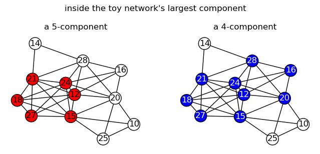

```python
kcomps = nx.algorithms.connectivity.k_components(lcomp)
kmax = list(kcomps.keys())[0]

plt.figure(figsize=(8, 3))
plt.suptitle('inside the toy network\'s largest component', y=1.07)

kcomp = kcomps[kmax][0]
plt.subplot(121)
plt.title('a %d-component' % kmax)
nx.draw(lcomp, pos=lcomp.graph['pos'], with_labels=True, edgecolors='k',
        node_color=['r' if n in kcomp else 'w' for n in lcomp.nodes])

kcomp = kcomps[kmax-1][0]
plt.subplot(122)
plt.title('a %d-component' % (kmax-1))
nx.draw_networkx_labels(lcomp, pos=lcomp.graph['pos'], font_color='w',
                        labels={n: n for n in kcomp})
nx.draw_networkx_labels(lcomp, pos=lcomp.graph['pos'], font_color='k',
                        labels={n: n for n in set(lcomp.nodes)-kcomp})
nx.draw(lcomp, pos=lcomp.graph['pos'], edgecolors='k',
        node_color=['b' if n in kcomp else 'w' for n in lcomp.nodes])
```

# 6. Laplacian matrix

A network's Laplacian matrix $\mathbf{L}=\mathbf{D}-\mathbf{A}$ is the difference between its degree matrix $\mathbf{D}$ and adjacency matrix $\mathbf{A}$. You can calculate it manually or obtain it with `laplacian_matrix`, which returns a SciPy matrix instead of a NumPy array.

```python
np.set_printoptions(threshold=100) # so that L will look smaller

A = nx.to_numpy_array(toy)
D = np.diag(A.sum(0)) # = np.diag([k for n, k in toy.degree])
L = (D-A).astype(int); L
```

```
array([[ 3,  0,  0, ...,  0,  0,  0],
       [ 0,  1,  0, ...,  0,  0,  0],
       [ 0,  0,  8, ..., -1, -1,  0],
       ...,
       [ 0,  0, -1, ...,  5,  0,  0],
       [ 0,  0, -1, ...,  0,  6,  0],
       [ 0,  0,  0, ...,  0,  0,  0]])
```

```python
L = nx.laplacian_matrix(toy).toarray().astype(int); L
```

```
array([[ 3,  0,  0, ...,  0,  0,  0],
       [ 0,  1,  0, ...,  0,  0,  0],
       [ 0,  0,  8, ..., -1, -1,  0],
       ...,
       [ 0,  0, -1, ...,  5,  0,  0],
       [ 0,  0, -1, ...,  0,  6,  0],
       [ 0,  0,  0, ...,  0,  0,  0]])
```

You can get its spectrum (i.e. its set of eigenvalues) with `laplacian_spectrum`. **Spectral graph theory** is devoted to study what kind of information is encoded in a network's spectrum. For example, the number of components on a network is found to be equal to the number of zeros in its spectrum.

```python
spectrum = nx.laplacian_spectrum(toy)
print('Number of zeros in the spectrum:', (spectrum<1e-6).sum())
np.round(spectrum, 6)
```

```
Number of zeros in the spectrum: 7
```

```
array([-0.      , -0.      ,  0.      ,  0.      ,  0.      ,  0.      ,
        0.      ,  1.472957,  2.      ,  2.      ,  2.154067,  3.254855,
        4.      ,  6.      ,  6.064521,  7.500853,  7.848572,  9.      ,
        9.225706,  9.478468])
```

# References

1. Dijkstra E. W. (1959) *A note on two problems in connexion with graphs*, Numer. Math. **1**, 269.
2. Floyd R. W. (1962) *Algorithm 97: Shortest Path*, Commun. ACM **5**, 345.
3. Kruskal J. B. (1956) *On the shortest spanning subtree of a graph and the traveling salesman problem*, Proc. Am. Math. Soc. **7**, 48.
4. Warshall S. (1962) *A theorem on Boolean matrices*, J. ACM **9**, 11.